# Diseño de experimentos

# 1 Conceptos básicos del diseño de experimentos

Fisher (1890 – 1962)fue uno de los creadores de diseño de experimentos. En Cambridge en 1912, estudió la teoría de errores. Introdujo el análisis de varianza, un procedimiento que hoy se usa en todo el mundo.

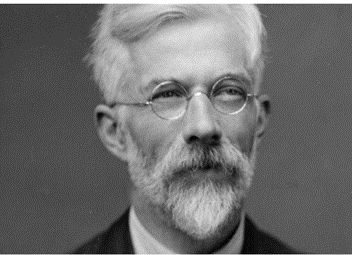

[figure not shown]

## 1.1 Generación de información válida

¿Qué entendemos por información válida?

- Objetiva: que no influya la opinión del sujeto
- Precisa: que sea exacto o riguroso
- Sistemática: que siga o se ajuste a un sistema
- Repetible: que se pueda volver a hacer de nuevo

Las reglas más utilizadas para generar este tipo de información son las contenidas en los principios básicos del diseño experimental.

Estos principios son las reglas científicamente adecuadas de hacer preguntas a los fenómenos estudiados bajo la forma de hipótesis.

## 1.2 Esquema de generación de información bajo un programa de investigación

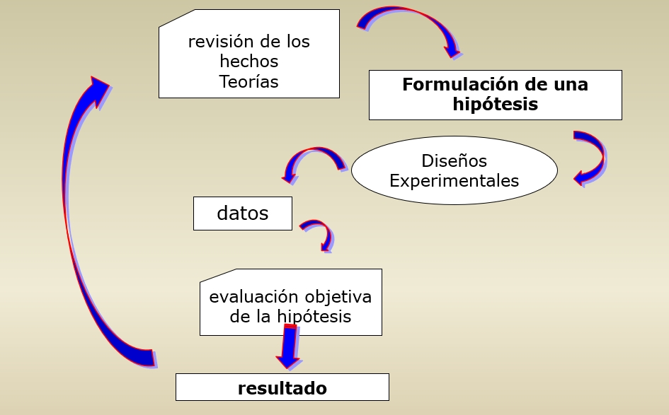

Diseñar es una forma de asegurarse que se tomaran los datos que nos generen decisiones válidas para el problema planteado.

Consiste en planificar el experimento de manera tal que se pueda obtener la información más adecuada al menos costo posible, que pueda ser analizados mediante técnicas estadísticas.

## 1.3 Cómo elegir un diseño

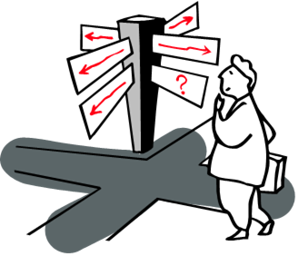

Algunas preguntas que ayudan a elegir el diseño son:

- ¿Cuáles son las características a analizar?
- ¿Qué factores afectan esas características?
- ¿Cuántas veces debiera repetirse cada tratamiento?
- ¿Cuál debiera ser la forma de análisis?
- ¿A partir de cuál valor se considera importante un efecto?

## 1.4 Definiciones útiles para el diseño de un experimento

### 1.4.1 Variable respuesta:

Observaciones o mediciones realizadas en un experimento

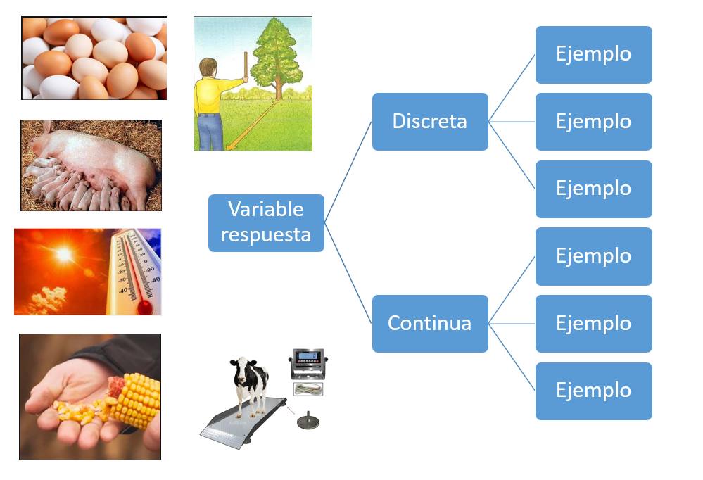

### 1.4.2 Tratamiento

Factor o combinación de factores cuyo efecto será medido y/o comparado con otros niveles del factor. Por ejemplo, en el área agronómica:

- Dosis de un herbicida para un determinado cultivo.
- Fecha de aplicación de un herbicida.
- Combinación de temperatura y humedad sobre una labranza.
- Distintos genotipos.
- Distintos métodos de siembra.

### 1.4.3 Unidad experimental

La menor unidad del material experimental a la que se le aplica un solo tratamiento y se le permite actuar en forma independiente, es decir que no se halle influenciada por el efecto de otro tratamiento.

Por ejemplo, en el área agronómica:

- un novillo,
- una parcela,
- una hoja,
- una planta.

### 1.4.4 Unidad de muestreo

Unidad sobre la que se mide el efecto del tratamiento.

Puede ser toda o parte de la unidad experimental.

Por ejemplo, interesa estudiar el efecto de varias dosis de un herbicida (cada dosis es un tratamiento) sobre cierta variedad de soja, sembrada en parcelas compuestas de 5 hileras de 30 m (la parcela es la unidad experimental).

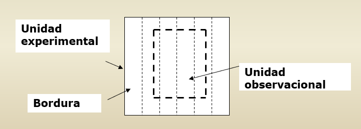

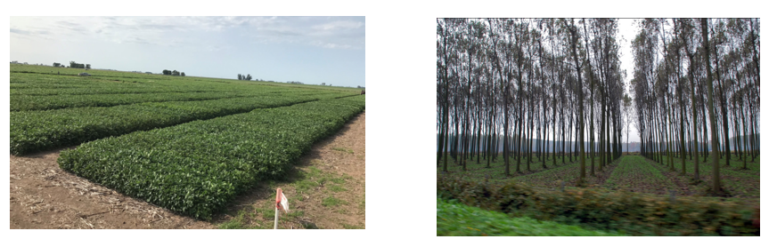

### 1.4.5 Error Experimental

Medida de la variación que existe entre unidades experimentales igualmente tratadas.

Mide el “fracaso” de llegar a resultados idénticos con dos o más unidades experimentales con igual tratamiento.

- errores de experimentación,
- errores de observación,
- errores de medición,
- variación del material experimental, etc.

Por ejemplo, dos parcelas sembradas con cierta variedad de soja tratadas con la misma dosis de herbicida.

Es muy improbable que produzcan el mismo rendimiento, aunque no haya errores de experimentación ni errores de medición, debido generalmente a:

• variaciones de suelo,

• de fertilidad de las semillas,

• profundidad de siembra, • etc..

## 1.5 Principios básicos del diseño experimental

Una vez que determinamos nuestras preguntas debemos pensar en el modelo acerca del aspecto que estamos interesados y diseñar un experimento que nos permita evaluarlo

- REPETICION
- ALEATORIZACION
- CONTROL LOCAL

### 1.5.1 Repetición

El ensayo debiera ser conducido de manera de disponer de dos o más unidades experimentales tratadas con el mismo tratamiento.

Cada una de estas unidades experimentales es una repetición.

No se consideran repeticiones a dos o más mediciones de una misma unidad experimental.

La obtención de repeticiones permite, calcular una estimación del error experimental.

Esta es la unidad de medición básica para determinar si las diferencias observadas entre tratamientos son estadísticamente significativas; es decir si esas diferencias se deben al azar o son importantes con relación al error experimental.

## 1.6 Situaciones frente a un experimento

Modelos supuesto: altura al momento de trasplante: efecto del fungicida + efectos no controlados.

Variabilidad Total = Variabilidad entre tratamientos + variabilidad dentro tratamiento.

Las pruebas estadísticas simplemente comparar si la variabilidad entre los tratamientos es mayor a la de dentro de los tratamientos o error experimental

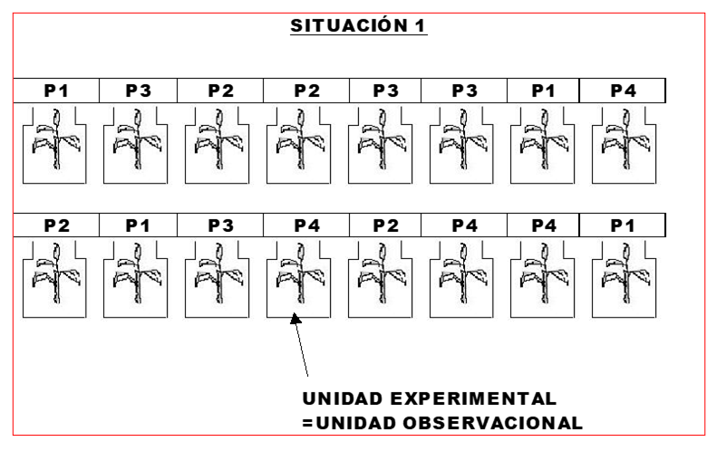

Mido cada plántula

¿Cantidad de observaciones?:

¿Repeticiones por tratamiento?:

¿Variabilidad entre tratamiento y Variabilidad dentro tratamiento se pueden separar?

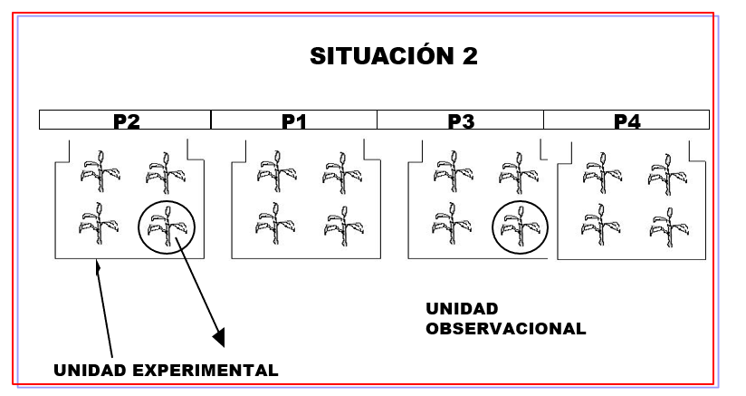

Mido cada plántula

¿Cantidad de observaciones?:

¿Repeticiones por tratamiento?:

¿Variabilidad entre tratamiento y Variabilidad dentro tratamiento se pueden separar?

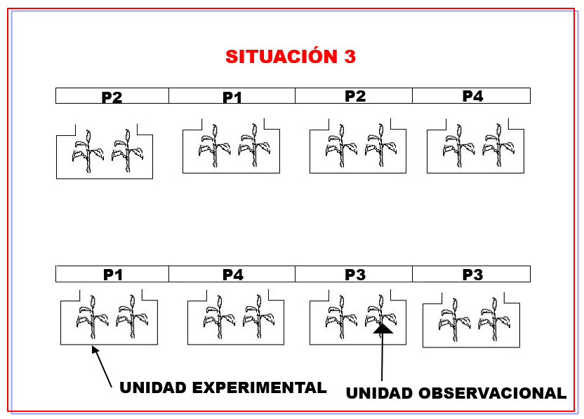

Mido cada plántula

¿Cantidad de observaciones?:

¿Repeticiones por tratamiento?:

¿Variabilidad entre tratamiento y Variabilidad dentro tratamiento se pueden separar?

## 1.7 Cómo generar aleatorizacion para nuestros diseños

El paquete “agricolae” presenta funciones especiales para la creación del libro de campo para diseños experimentales. La generación aleatoria hace que este paquete sea bastante utilizado en la investigación agrícola.

Para esta generación se requiere ciertos parámetros como por ejemplo el nombre de cada uno de los tratamientos, el número de repeticiones y otros según el diseño (Cochran 1992; Kuehl, 2000; Montgomery, 2002; LeClerg, 1962).

Otros parámetros de generación aleatoria son adicionales, como la semilla para reproducir la misma generación aleatoria o el método de generación (Ver manual de referencia de agrícola http://cran.at.r-project.org/web/packages/agricolae/agricolae.pdf)

### 1.7.1 DCA

Sólo se requiere los nombres de tratamientos y el número de sus repeticiones,

```r
library(agricolae)
trt <- c("A", "B", "C")
repeticion <- c(4, 4, 4)
plan1 <- design.crd(trt,r=repeticion)
```

| plots | r | trt |
| --- | --- | --- |
| 101 | 1 | B |
| 102 | 1 | C |
| 103 | 2 | B |
| 104 | 1 | A |
| 105 | 3 | B |
| 106 | 2 | C |
| 107 | 2 | A |
| 108 | 3 | C |
| 109 | 4 | C |
| 110 | 3 | A |
| 111 | 4 | A |
| 112 | 4 | B |

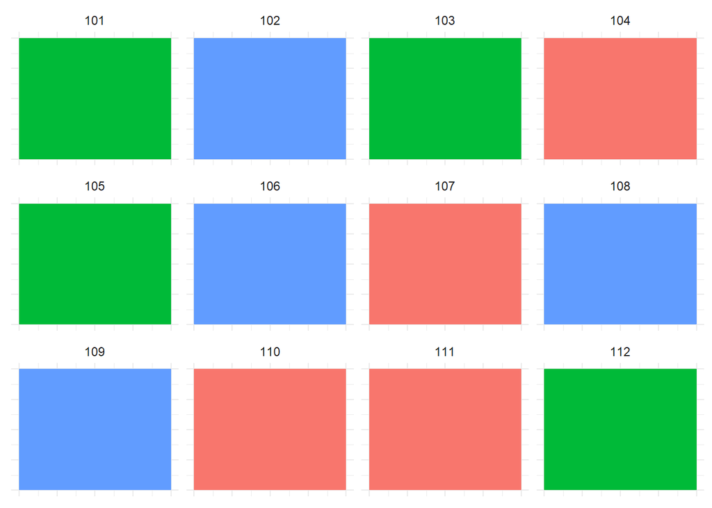

```r
write.csv(plan1,"plan1.csv",row.names=FALSE)
```

Para Excel.

### 1.7.2 DBCA

Se requiere los nombres de tratamientos y el número de bloques.

```r
trt <- c("A", "B", "C")
repeticion <- 4
plan2 <- design.rcbd(trt,r=repeticion, seed=55)
```

| plots | block | trt |
| --- | --- | --- |
| 101 | 1 | B |
| 102 | 1 | C |
| 103 | 1 | A |
| 201 | 2 | A |
| 202 | 2 | B |
| 203 | 2 | C |
| 301 | 3 | A |
| 302 | 3 | B |
| 303 | 3 | C |
| 401 | 4 | A |
| 402 | 4 | B |
| 403 | 4 | C |

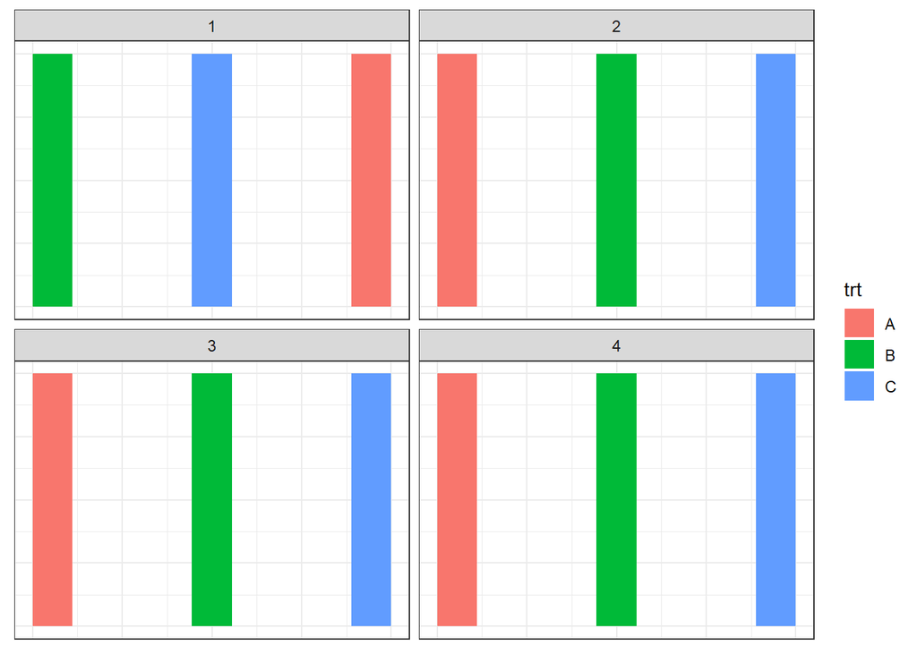

### 1.7.3 CUADRADO LATINO

Se requiere los nombres de tratamientos.

```r
trt <- c("A", "B", "C", "D")
plan3 <- design.lsd(trt, seed=55)
```

| plots | row | col | trt |
| --- | --- | --- | --- |
| 101 | 1 | 1 | D |
| 102 | 1 | 2 | A |
| 103 | 1 | 3 | B |
| 104 | 1 | 4 | C |
| 201 | 2 | 1 | B |
| 202 | 2 | 2 | C |
| 203 | 2 | 3 | D |
| 204 | 2 | 4 | A |
| 301 | 3 | 1 | C |
| 302 | 3 | 2 | D |
| 303 | 3 | 3 | A |
| 304 | 3 | 4 | B |
| 401 | 4 | 1 | A |
| 402 | 4 | 2 | B |
| 403 | 4 | 3 | C |
| 404 | 4 | 4 | D |

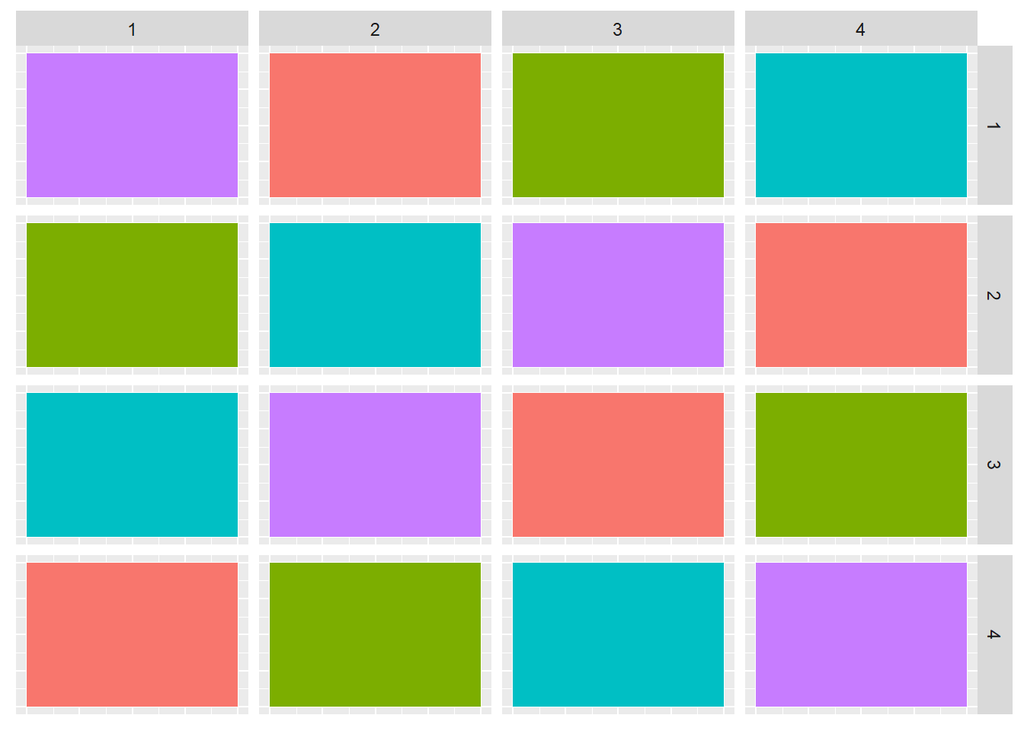

## 1.8 Ejemplos de investigación

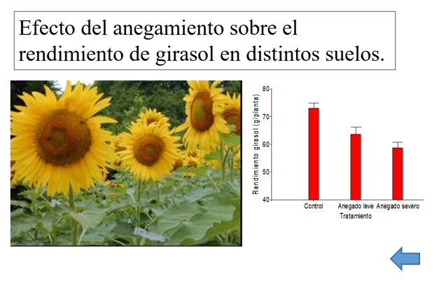

Comparación el rendimiento de plantas de girasol bajo diferentes condiciones de anegamiento en 6 macetas diferentes (18 en total).

- ¿Cuál es el objetivo de la investigación?
- ¿Cuáles son los tratamientos?
- ¿Cuál es la unidad experimental?
- ¿Qué se midió?
- ¿Dan el mismo resultado las macetas igualmente tratadas?
- ¿Por qué en este caso?
- ¿Control?
- Para qué?

## 1.9 Bibliografía

Cochran, W. G., and Cox, G. M. (1992). Experimental Designs. John Wiley & Sons, New York.

Kuehl, R. O. (2000). Designs of Experiments: Statistical Principles of Research Design and Analysis. Duxbury Press.

Le Clerg, E. L., Leonard, W. H., Erwin, L., Warren, H. L., and Andrew, G. C. (1962). Field Plot Techniques. Burgess Publishing Company, Minneapolis, Minnesota.

Montgomery, D. C. (2002). Design and Analysis of Experiments. John Wiley & Sons, New York.